# JB Baseline - Reefs

Molly Wilson

8/14/2022

## Benthic

```r
# import and clean data

rf_benthic <- read_excel(here("jumby_baseline", "data", "JBB_reefs.xlsx"), sheet = "benthic") %>%
  clean_names() %>%
  filter(!is.na(site)) %>% # remove any incomplete rows at the end of the data
  # separate(species_code, c("species_code", "indicator")) %>% # separating variables with an underscore into two columns
  mutate(species = to_any_case(species, case = "sentence"), # this makes sure species names are correctly capitalized
         # site = to_any_case(site, case = "title"),
         # consolidating categories here for graphs:
         cat_c = case_when(category_code %in% c("LC", "SLC") ~ "Hard corals",
                                  category_code %in% c("MA") ~ "Macroalgae",
                                  category_code %in% c("TA") ~ "Turf algae",
                                  category_code %in% c("CCA", "CCA_ND") ~ "CCA",
                                  category_code %in% c("OINV", "SPON", "AINV", "CYAN", "PEY") ~ "Other competitors",
                                  category_code %in% c("SAND", "HOLE", "SG", "PAVE") ~ "Other substratum"
                                    ),
         # adding algal type for graphs about palatability:
         algal_type = case_when(type_code %in% c("BFMA", "GFMA", "RFMA") ~ "Fleshy macroalgae",
                                type_code %in% c("GCMA", "RCMA") ~ "Calcareous macroalgae",
                                type_code %in% c("TA", "TAS", "STA") ~ "Turf algae"),
         # certain substrates are not suitable for coral or algal growth, so should not detract from percent cover
         av_sub_yn = if_else(category_code %in% c("SAND", "HOLE", "SG", "PAVE"), "no", "yes")
         ) %>%
    filter(!is.na(cat_c) & !is.na(species)) # need GRB to fix some data errors, but using this for now
```

### Percent cover

#### Percent cover by site and category - summary categories

```r
# "expand" dataframe so that it contains all benthic categories per site/transect/meter -> join full dataset so that any meters where a species was absent it will show up as 0 (as opposed to having no entry)
rf_pc_cat_m <- rf_benthic %>%
  filter(av_sub_yn == "yes") %>% # percent cover is relative to available substrate
  expand(nesting(site, transect, meter), cat_c) %>%
  # this is where we add in our actual data to this expanded template:
  left_join(rf_benthic %>%
              filter(av_sub_yn == "yes") %>% # only looking at what is considered available substrate (no sand, etc.)
              group_by(site, transect, meter) %>%
              mutate(n_pts = n()) %>% # showing total number of points per meter that are considered available substrate
              ungroup() %>%
              group_by(site, transect, meter, n_pts, cat_c) %>%
              summarize(pc_m = 100*n()/n_pts) %>% # n() counts the number of entries within a given group
              ungroup() %>%
              distinct() %>%
              select(-n_pts),
            by = c("site", "transect", "meter", "cat_c")) %>%
  mutate(pc_m = if_else(is.na(pc_m), 0, pc_m))

# average these meter-level results within transect, then within sites
rf_pc_cat_site <- rf_pc_cat_m %>%
  group_by(site, transect, cat_c) %>%
  summarize(pc_t = mean(pc_m)) %>%
  ungroup() %>%
  group_by(site, cat_c) %>%
  summarize(n_test = n(),
            pc_mean = mean(pc_t),
            pc_se = sd(pc_t)/sqrt(n())
            ) %>%
  filter(cat_c != "Other substratum") %>%
  mutate(cat_c = factor(cat_c, levels = c("Hard corals", "CCA", "Macroalgae", "Turf algae", "Other competitors")))

# quick check to make sure everything adds up to 100% at the meter and site level
test1 <- rf_pc_cat_m %>%
  group_by(site, transect, meter) %>%
  summarize(total = sum(pc_m))
test2 <- rf_pc_cat_site %>%
  group_by(site) %>%
  summarize(total = sum(pc_mean))
```

```r
cat_palette <- c("coral2", "pink", "darkolivegreen", "darkkhaki", "slategray3")
ggplot(rf_pc_cat_site,
       aes(x = cat_c, y = pc_mean, fill = cat_c)) +
  geom_col(color = "black", alpha = 0.9) +
  geom_errorbar(aes(ymin = pc_mean - pc_se, ymax = pc_mean + pc_se), width = .2,
                 position = position_dodge(.9)) +
  scale_fill_manual(values = cat_palette) +
  facet_wrap(. ~ site, ncol = 2) +
  labs(y = "Mean percent cover", x = "", fill = "") +
  theme_bw() +
  theme(axis.text.x = element_text(angle = 45, h = 1, face = "italic"))
```

[output not shown]

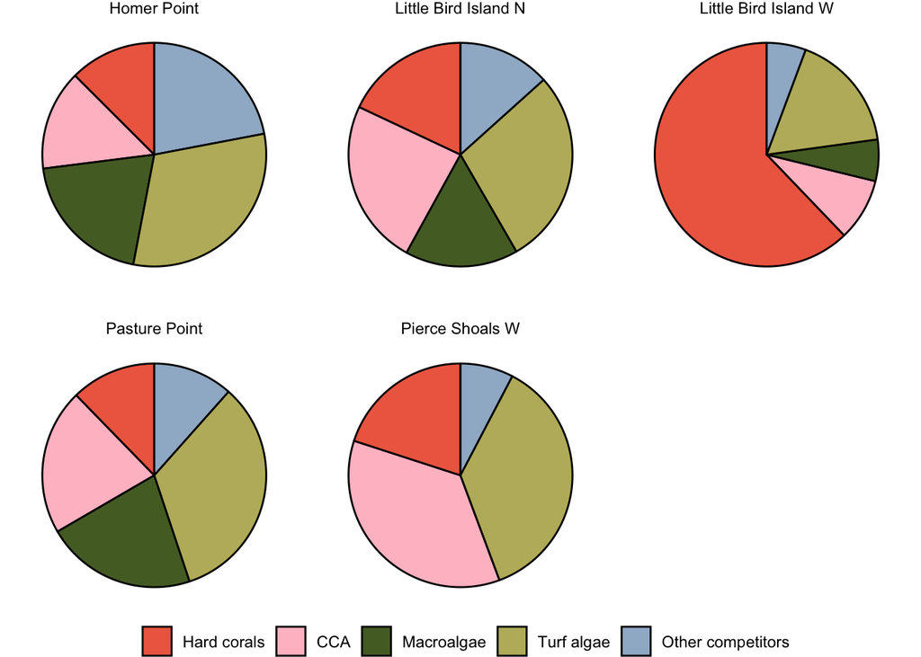

```r
cat_palette <- c("coral2", "pink", "darkolivegreen", "darkkhaki", "slategray3")
ggplot(rf_pc_cat_site,
       aes(x = "cat_c", y = pc_mean, fill = cat_c)) +
  geom_bar(width = 1, stat = "identity", color = "black") +
  coord_polar("y", start=0) +
  scale_fill_manual(values = cat_palette) +
  facet_wrap(vars(site), nrow = 2) +
  theme_void() +
  theme(legend.position = "bottom",
        legend.title = element_blank(),
        panel.spacing = unit(1, "lines"))
```

```r
ggsave(here("jumby_baseline", "figs", "reef_benthic_pc.png"))

kable(rf_pc_cat_site %>% select(site, category = cat_c, pc_mean, pc_se))
```

| site | category | pc_mean | pc_se |
| --- | --- | --- | --- |
| Homer Point | CCA | 14.500000 | 3.5000000 |
| Homer Point | Hard corals | 12.500000 | 7.5000000 |
| Homer Point | Macroalgae | 20.000000 | 15.0000000 |
| Homer Point | Other competitors | 22.000000 | 7.0000000 |
| Homer Point | Turf algae | 31.000000 | 4.0000000 |
| Little Bird Island N | CCA | 24.000000 | 5.1316014 |
| Little Bird Island N | Hard corals | 18.000000 | 2.0816660 |
| Little Bird Island N | Macroalgae | 16.333333 | 4.0551750 |
| Little Bird Island N | Other competitors | 13.333333 | 0.6666667 |
| Little Bird Island N | Turf algae | 28.333333 | 4.9103066 |
| Little Bird Island W | CCA | 9.037037 | 1.7642230 |
| Little Bird Island W | Hard corals | 62.148148 | 7.9572762 |
| Little Bird Island W | Macroalgae | 6.000000 | 4.5825757 |
| Little Bird Island W | Other competitors | 5.666667 | 1.2018504 |
| Little Bird Island W | Turf algae | 17.148148 | 5.0537577 |
| Pasture Point | CCA | 21.111111 | 5.8888889 |
| Pasture Point | Hard corals | 12.277778 | 1.2777778 |
| Pasture Point | Macroalgae | 21.722222 | 3.7222222 |
| Pasture Point | Other competitors | 11.555556 | 3.4444444 |
| Pasture Point | Turf algae | 33.333333 | 4.3333333 |
| Pierce Shoals W | CCA | 35.666667 | 8.0897741 |
| Pierce Shoals W | Hard corals | 20.000000 | 7.8102497 |
| Pierce Shoals W | Macroalgae | 0.000000 | 0.0000000 |
| Pierce Shoals W | Other competitors | 7.666667 | 2.4037009 |
| Pierce Shoals W | Turf algae | 36.666667 | 3.1797973 |

### Percent cover by species

```r
# calculating percent cover by species at each meter
rf_pc_spp_m <- rf_benthic %>%
  filter(av_sub_yn == "yes") %>%
  expand(nesting(site, transect, meter), nesting(species, cat_c)) %>%
  left_join(rf_benthic %>%
              filter(av_sub_yn == "yes") %>%
              group_by(site, transect, meter) %>%
              mutate(n_pts = n()) %>%
              ungroup() %>%
              group_by(site, transect, meter, n_pts, species, cat_c) %>%
              summarize(pc_m = 100*n()/n_pts) %>%
              ungroup() %>%
              distinct() %>%
              select(-n_pts),
            by = c("site", "transect", "meter", "species", "cat_c")) %>%
  mutate(pc_m = if_else(is.na(pc_m), 0, pc_m))

# calculating mean percent cover by transect -> site
rf_pc_spp_site <- rf_pc_spp_m %>%
  group_by(site, transect, species, cat_c) %>%
  summarize(pc_t = mean(pc_m)) %>%
  ungroup() %>%
  group_by(site, species, cat_c) %>%
  summarize(pc_mean = mean(pc_t),
            pc_se = sd(pc_t)/sqrt(n())
            ) %>%
  ungroup() %>%
  distinct()

# calculating mean percent cover by species across all sites
rf_pc_spp <- rf_pc_spp_site %>%
  group_by(species, cat_c) %>%
  summarize(pc = mean(pc_mean),
            pc_se = sd(pc_mean)/sqrt(n())) %>%
  rename(pc_mean = pc)

# testing that total percent cover per transect and site add up to 100
test1 <- rf_pc_spp_m %>%
  group_by(site, transect, meter) %>%
  summarize(total = sum(pc_m))
test2 <- rf_pc_spp_site %>%
  group_by(site) %>%
  summarize(total = sum(pc_mean))
test3 <- sum(rf_pc_spp$pc_mean)
```

#### Stony coral - percent cover by species across all sites

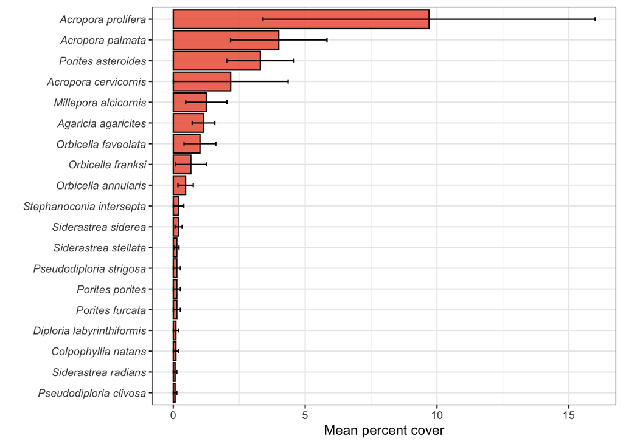

```r
ggplot(rf_pc_spp %>%
         filter(cat_c == "Hard corals"),
       aes(x = reorder(species, pc_mean), y = pc_mean)) +
  geom_col(fill = "coral2", color = "black", alpha = 0.9) +
  geom_errorbar(aes(ymin = pc_mean - pc_se, ymax = pc_mean + pc_se), width = .2,
                 position = position_dodge(.9)) +
  coord_flip() +
  labs(y = "Mean percent cover", x = "", fill = "") +
  theme_bw() +
  theme(axis.text.y = element_text(face = "italic"))
```

```r
ggsave(here("jumby_baseline", "figs", "reef_coral_spp.png"))

kable(rf_pc_spp %>% filter(cat_c == "Hard corals") %>% select(species, pc_mean, pc_se))
```

| species | pc_mean | pc_se |
| --- | --- | --- |
| Acropora cervicornis | 2.1777778 | 2.1777778 |
| Acropora palmata | 4.0000000 | 1.8287822 |
| Acropora prolifera | 9.7000000 | 6.3000000 |
| Agaricia agaricites | 1.1444444 | 0.4287507 |
| Colpophyllia natans | 0.1000000 | 0.1000000 |
| Diploria labyrinthiformis | 0.1000000 | 0.1000000 |
| Millepora alcicornis | 1.2518519 | 0.7804539 |
| Orbicella annularis | 0.4666667 | 0.2905933 |
| Orbicella faveolata | 1.0111111 | 0.6041012 |
| Orbicella franksi | 0.6666667 | 0.5868939 |
| Porites asteroides | 3.3000000 | 1.2741010 |
| Porites furcata | 0.1333333 | 0.1333333 |
| Porites porites | 0.1333333 | 0.1333333 |
| Pseudodiploria clivosa | 0.0666667 | 0.0666667 |
| Pseudodiploria strigosa | 0.1333333 | 0.1333333 |
| Siderastrea radians | 0.0666667 | 0.0666667 |
| Siderastrea siderea | 0.2000000 | 0.1333333 |
| Siderastrea stellata | 0.1333333 | 0.0816497 |
| Stephanoconia intersepta | 0.2000000 | 0.2000000 |

#### Other competitors - percent cover by species at each sites

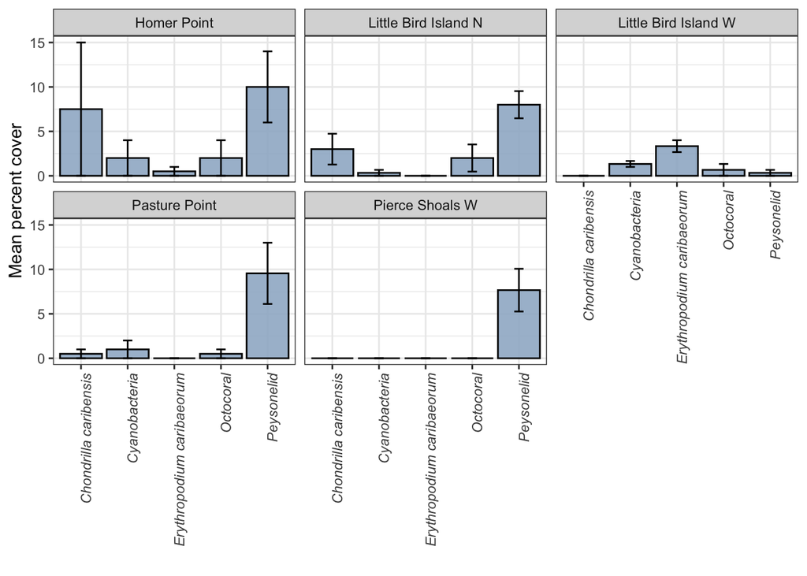

```r
ggplot(rf_pc_spp_site %>%
         filter(cat_c == "Other competitors"),
       aes(x = species, y = pc_mean)) +
  geom_col(fill = "slategray3", color = "black", alpha = 0.9) +
  geom_errorbar(aes(ymin = pc_mean - pc_se, ymax = pc_mean + pc_se), width = .2,
                 position = position_dodge(.9)) +
  facet_wrap(. ~ site, ncol = 3) +
  labs(y = "Mean percent cover", x = "", fill = "") +
  theme_bw() +
  theme(axis.text.x = element_text(face = "italic", angle = 90, hjust = 1))
```

```r
#ggsave(here("jumby_baseline", "figs", "reef_coral_spp.png"))

kable(rf_pc_spp_site %>% filter(cat_c == "Other competitors") %>% select(site, species, pc_mean, pc_se))
```

| site | species | pc_mean | pc_se |
| --- | --- | --- | --- |
| Homer Point | Chondrilla caribensis | 7.5000000 | 7.5000000 |
| Homer Point | Cyanobacteria | 2.0000000 | 2.0000000 |
| Homer Point | Erythropodium caribaeorum | 0.5000000 | 0.5000000 |
| Homer Point | Octocoral | 2.0000000 | 2.0000000 |
| Homer Point | Peysonelid | 10.0000000 | 4.0000000 |
| Little Bird Island N | Chondrilla caribensis | 3.0000000 | 1.7320508 |
| Little Bird Island N | Cyanobacteria | 0.3333333 | 0.3333333 |
| Little Bird Island N | Erythropodium caribaeorum | 0.0000000 | 0.0000000 |
| Little Bird Island N | Octocoral | 2.0000000 | 1.5275252 |
| Little Bird Island N | Peysonelid | 8.0000000 | 1.5275252 |
| Little Bird Island W | Chondrilla caribensis | 0.0000000 | 0.0000000 |
| Little Bird Island W | Cyanobacteria | 1.3333333 | 0.3333333 |
| Little Bird Island W | Erythropodium caribaeorum | 3.3333333 | 0.6666667 |
| Little Bird Island W | Octocoral | 0.6666667 | 0.6666667 |
| Little Bird Island W | Peysonelid | 0.3333333 | 0.3333333 |
| Pasture Point | Chondrilla caribensis | 0.5000000 | 0.5000000 |
| Pasture Point | Cyanobacteria | 1.0000000 | 1.0000000 |
| Pasture Point | Erythropodium caribaeorum | 0.0000000 | 0.0000000 |
| Pasture Point | Octocoral | 0.5000000 | 0.5000000 |
| Pasture Point | Peysonelid | 9.5555556 | 3.4444444 |
| Pierce Shoals W | Chondrilla caribensis | 0.0000000 | 0.0000000 |
| Pierce Shoals W | Cyanobacteria | 0.0000000 | 0.0000000 |
| Pierce Shoals W | Erythropodium caribaeorum | 0.0000000 | 0.0000000 |
| Pierce Shoals W | Octocoral | 0.0000000 | 0.0000000 |
| Pierce Shoals W | Peysonelid | 7.6666667 | 2.4037009 |

### Macroalgal canopy heights

- No macroalgae present at Pierce Shoals W
- Macroalgae only present on one transect at Pasture Point, hence no standard error can be calculated

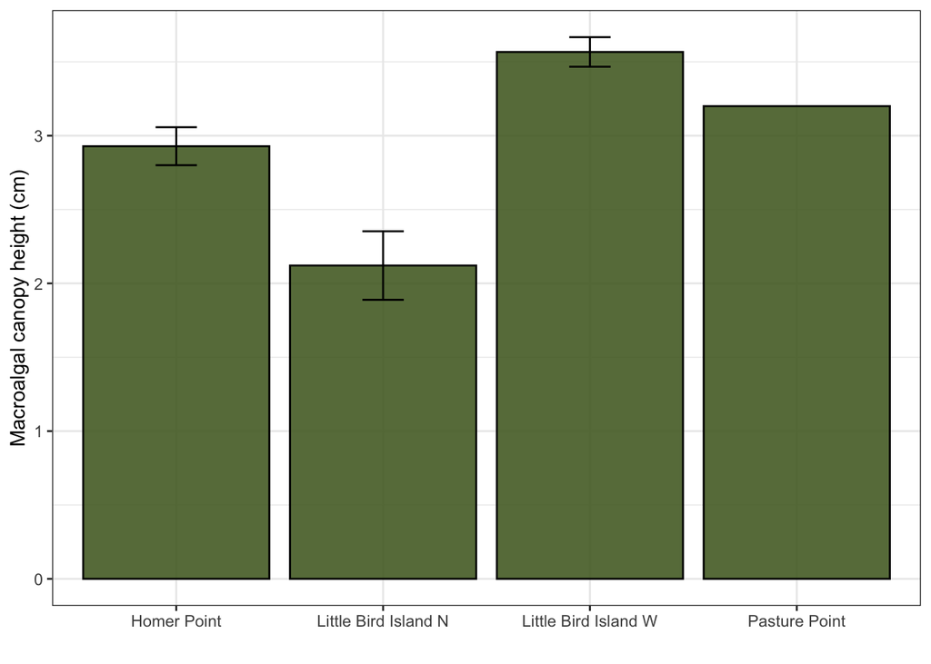

```r
ma_height <- rf_benthic %>%
  filter(category_code == "MA") %>%
  group_by(site, transect) %>%
  summarize(height = mean(height)) %>%
  filter(!is.na(height)) %>%
  group_by(site) %>%
  summarize(height_mean = mean(height),
            height_se = sd(height)/sqrt(n()))

ggplot(ma_height, aes(x = site, y = height_mean)) +
  geom_col(fill = "darkolivegreen", color = "black", alpha = 0.9) +
  geom_errorbar(aes(ymin = height_mean - height_se, ymax = height_mean + height_se), width = .2,
                 position = position_dodge(.9)) +
  labs(x = "", y = "Macroalgal canopy height (cm)") +
  theme_bw()
```

```r
ggsave(here("jumby_baseline", "figs", "reef_ma_height.png"))

kable(ma_height)
```

| site | height_mean | height_se |
| --- | --- | --- |
| Homer Point | 2.928571 | 0.1285714 |
| Little Bird Island N | 2.120915 | 0.2320261 |
| Little Bird Island W | 3.566667 | 0.1000000 |
| Pasture Point | 3.200000 | NA |

### Macroalgal index

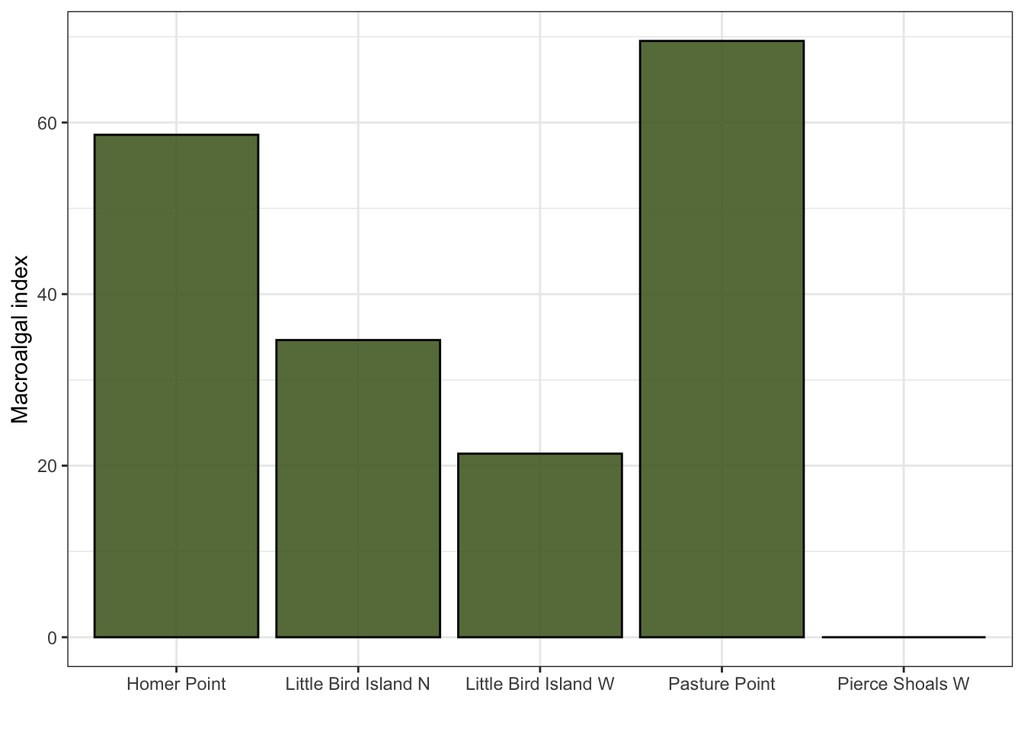

```r
ma_index <- rf_pc_cat_site %>%
  filter(cat_c == "Macroalgae") %>%
  left_join(ma_height) %>%
  mutate(index = height_mean * pc_mean,
         index = if_else(is.na(index), 0, index))

ggplot(ma_index, aes(x = site, y = index)) +
  geom_col(fill = "darkolivegreen", color = "black", alpha = 0.9) +
  labs(x = "", y = "Macroalgal index") +
  theme_bw()
```

```r
kable(ma_index %>% select(site, index))
```

| site | index |
| --- | --- |
| Homer Point | 58.57143 |
| Little Bird Island N | 34.64161 |
| Little Bird Island W | 21.40000 |
| Pasture Point | 69.51111 |
| Pierce Shoals W | 0.00000 |

### Coral recruits

```r
rf_recruits <- read_excel(here("jumby_baseline", "data", "JBB_reefs.xlsx"), sheet = "recruits") %>%
  clean_names() %>%
  pivot_longer(cols = starts_with("count"),
               names_to = "size",
               names_pattern = "count_(.*)",
               values_to = "count") %>%
  mutate(size = if_else(size == "0_2cm", "<2 cm", "2-4 cm")) %>%
  select(site, transect, meter, size, code, species, count)
```

#### Density of coral recruits (all species) by site

- Need to check size of quadrats

```r
# by size
rf_recruits_size <- rf_recruits %>%
  group_by(site, transect, size, meter) %>%
  summarize(count = sum(count)) %>%
  group_by(site, transect, size) %>%
  summarize(density = mean(count/(5 * 0.25 * 0.25))) %>% # 5 25cm x 25cm quadrats per transect
  group_by(site, size) %>%
  summarize(density_mean = mean(density),
            density_se = sd(density)/sqrt(n())) # se = mean here, which I assume just means there is a lot of variation/not many samples

ggplot(rf_recruits_size, aes(x = site, y = density_mean)) +
  geom_col(fill = "coral2", color = "black", alpha = 0.9) +
  geom_errorbar(aes(ymin = density_mean - density_se, ymax = density_mean + density_se), width = .2,
                 position = position_dodge(.9)) +
  labs(x = "", y = expression(Larval~recruit~density~(recruits~m^-2))) +
  facet_wrap(. ~ size) +
  theme_bw() +
  theme(axis.text.x = element_text(angle = 45, h = 1))

kable(rf_recruits_size)
```

[output not shown]

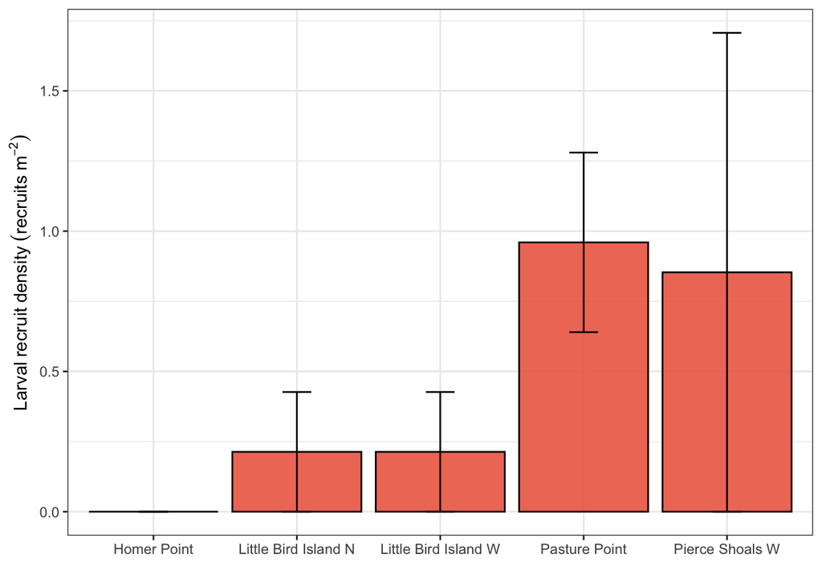

```r
# grouped across sizes
rf_recruits_tot <- rf_recruits %>%
  group_by(site, transect, meter) %>%
  summarize(count = sum(count)) %>%
  group_by(site, transect) %>%
  summarize(density = mean(count/(5 * 0.25 * 0.25))) %>%
  group_by(site) %>%
  summarize(density_mean = mean(density),
            density_se = sd(density)/sqrt(n())) # se = mean here, which I assume just means there is a lot of variation/not many samples

ggplot(rf_recruits_tot, aes(x = site, y = density_mean)) +
  geom_col(fill = "coral2", color = "black", alpha = 0.9) +
  geom_errorbar(aes(ymin = density_mean - density_se, ymax = density_mean + density_se), width = .2,
                 position = position_dodge(.9)) +
  labs(x = "", y = expression(Larval~recruit~density~(recruits~m^-2))) +
  theme_bw()
```

```r
ggsave(here("jumby_baseline", "figs", "reef_recruits.png"))

kable(rf_recruits_tot)
```

| site | density_mean | density_se |
| --- | --- | --- |
| Homer Point | 0.0000000 | 0.0000000 |
| Little Bird Island N | 0.2133333 | 0.2133333 |
| Little Bird Island W | 0.2133333 | 0.2133333 |
| Pasture Point | 0.9600000 | 0.3200000 |
| Pierce Shoals W | 0.8533333 | 0.8533333 |

#### Proportion of coral recruits by species

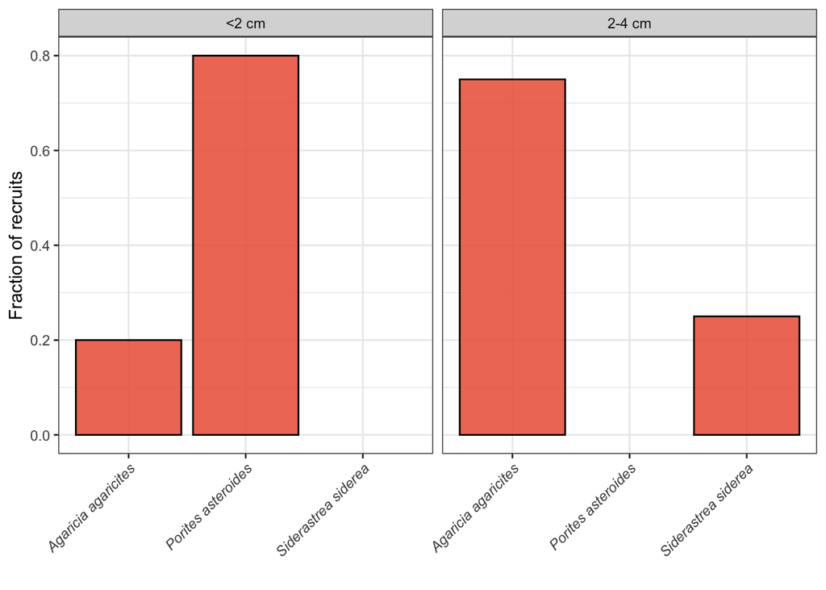

```r
rf_recruits_spp <- rf_recruits %>%
  filter(count > 0) %>%
  uncount(count) %>%
  group_by(size, species) %>%
  summarize(n = n()) %>%
  mutate(freq = n / sum(n))

ggplot(rf_recruits_spp, aes(x = species, y = freq)) +
  geom_col(fill = "coral2", color = "black", alpha = 0.9) +
  facet_wrap(. ~ size) +
  labs(x = "", y = "Fraction of recruits") +
  theme_bw() +
  theme(axis.text.x = element_text(angle = 45, h = 1, face = "italic"))
```

### Diadema

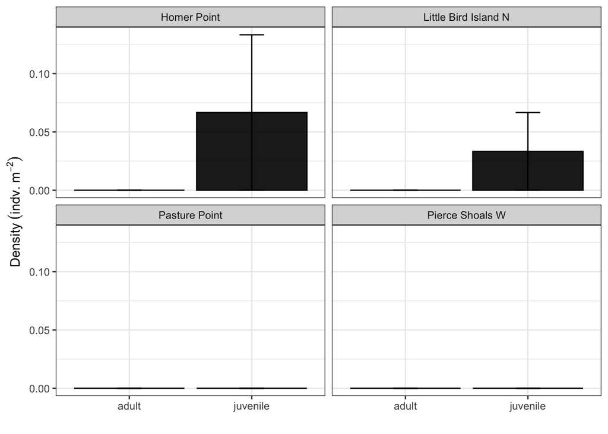

```r
diadema <- rf_recruits <- read_excel(here("jumby_baseline", "data", "JBB_reefs.xlsx"), sheet = "inverts") %>%
  clean_names() %>%
  select(site, transect, diadema_adult, diadema_juvenile) %>%
  pivot_longer(cols = starts_with("diadema"),
               names_to = "phase",
               names_pattern = "diadema_(.*)",
               values_to = "count")

diadema_ph <- diadema %>%
  group_by(site, phase) %>%
  summarize(density_mean = mean(count/10), # 1x10m belt
            density_se = sd(count/10)/sqrt(n()))

ggplot(diadema_ph, aes(x = phase, y = density_mean)) +
  geom_col(fill = "black", color = "black", alpha = 0.9) +
  geom_errorbar(aes(ymin = density_mean - density_se, ymax = density_mean + density_se), width = .2,
                 position = position_dodge(.9)) +
  facet_wrap(. ~ site) +
  labs(x = "", y = expression(Density~(indv.~m^-2))) +
  theme_bw()
```

```r
diadema_sum <- diadema %>%
  group_by(site, transect) %>%
  summarize(density = sum(count)/10) %>%
  group_by(site) %>%
  summarize(dens_mean = mean(density))

diadema_mean <- tibble(dens_mean = mean(diadema_sum$dens_mean),
                       dens_se = sd(diadema_sum$dens_mean)/sqrt(4))
kable(diadema_mean)
```

| dens_mean | dens_se |
| --- | --- |
| 0.025 | 0.0159571 |

## Fish

```r
# import and clean data

rf_fish <- read_excel(here("jumby_baseline", "data", "JBB_reefs.xlsx"), sheet = "fish") %>%
  clean_names() %>%
  filter(!is.na(site)) %>% # remove any incomplete rows at the end of the data
  mutate(number = if_else(is.na(number), 1, number)) %>% # all entries with no number specified were single observations
  uncount(number) %>% # expand to replicate rows if multiple fish were recorded to look at length distributions
  mutate(biomass = as.numeric(biomass),
         phase_code = tolower(phase),
         phase = case_when(phase == "j" ~ "Juvenile",
                           phase == "i" ~ "Initial",
                           phase == "t" ~ "Terminal"),
         family_c = if_else(family %in% c("Scaridae", "Acanthuridae", "Haemulidae", "Serranidae", "Lutjanidae", "Balistidae", "Pomacentridae"), family, "Other"), # consolidating the number of families
         family_com = case_when(family_c == "Scaridae" ~ "Parrotfish",
                                family_c == "Acanthuridae" ~ "Surgeonfish",
                                family_c == "Haemulidae" ~ "Grunts",
                                family_c == "Serranidae" ~ "Grouper",
                                family_c == "Lutjanidae" ~ "Snapper",
                                family_c == "Balistidae" ~ "Triggerfish",
                                family_c == "Pomacentridae" ~ "Damselfish",
                                family_c == "Other" ~ "Other")
         )

n_transects <- rf_fish %>%
  select(site, transect) %>%
  distinct() %>%
  group_by(site) %>%
  summarize(n = n())
```

### Fish biomass

#### Total biomass at each site

```r
# calculating total biomass in each transect (sum) -> mean at each site
rf_fish_site <- rf_fish %>%
  group_by(site, transect) %>%
  summarize(bm_tot = sum(biomass)/1000/120*10000) %>% #kg/ha
  group_by(site) %>%
  summarize(bm_mean = mean(bm_tot),
            bm_se = sd(bm_tot)/sqrt(n()))
```

[figure not shown]

```r
# graph
ggplot(rf_fish_site, aes(x = site, y = bm_mean)) +
  geom_col(fill = "cadetblue3", color = "black", alpha = 0.8) +
  geom_errorbar(aes(ymin = bm_mean - bm_se, ymax = bm_mean + bm_se), width = .2,
                 position = position_dodge(.9)) +
  geom_hline(yintercept = 1300, linetype = "dashed", color = "black") +
  annotate("text", x = 5.5, y = 1350, size = 3, hjust = 1, label=c('Caribbean mean unfished biomass')) +
  geom_hline(yintercept = 591, linetype = "dashed", color = "black") +
  annotate("text", x = 5.5, y = 640, size = 3, hjust = 1, label=c('Antigua mean biomass')) +
  labs(x = "", y = expression(Total~fish~biomass~(kg~ha^-1))) +
  theme_bw()
```

```r
ggsave(here("jumby_baseline", "figs", "reef_fish_dens.png"))

kable(rf_fish_site %>% select(site, bm_mean, bm_se))
```

| site | bm_mean | bm_se |
| --- | --- | --- |
| Homer Point | NA | NA |
| Little Bird Island N | NA | NA |
| Little Bird Island W | NA | NA |
| Pasture Point | NA | NA |
| Pierce Shoals W | NA | NA |

### Biomass by site and family

- Need to reorder to put “other” last
- Are these good for families to feature?
- Should I switch to common family names, or both?

```r
# by site
rf_fish_fam_site <- rf_fish %>%
  expand(nesting(site, transect), family_c) %>%
  left_join(rf_fish %>%
      select(site, transect, family_c, length, biomass)) %>%
  mutate(biomass = if_else(is.na(biomass), 0, biomass)) %>%
  group_by(site, transect, family_c) %>%
  summarize(bm_tot = sum(biomass)/1000/120*10000) %>% #kg/ha
  group_by(site, family_c) %>%
  summarize(bm_mean = mean(bm_tot),
            bm_se = sd(bm_tot)/sqrt(n()))
```

```r
# graph
ggplot(rf_fish_fam_site, aes(x = family_c, y = bm_mean)) +
  geom_col(fill = "cadetblue3", color = "black", alpha = 0.9) +
  geom_errorbar(aes(ymin = bm_mean - bm_se, ymax = bm_mean + bm_se), width = .2,
                 position = position_dodge(.9)) +
  facet_wrap(. ~ site, ncol = 1) +
  labs(x = "", y = expression(Biomass~(kg~ha^-1))) +
  theme_bw() +
  theme(axis.text.x = element_text(angle = 45, h = 1))

kable(rf_fish_fam_site %>% select(site, family = family_c, bm_mean, bm_se))
```

[output not shown]

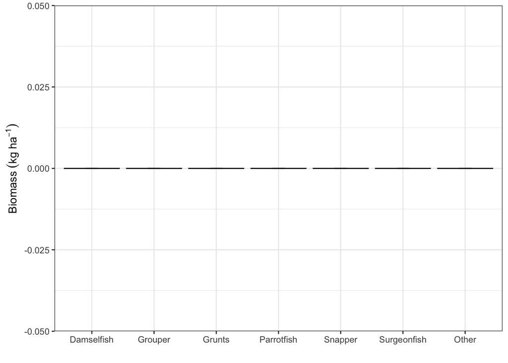

```r
rf_fish_fam <- rf_fish %>%
  expand(nesting(site, transect), family_com) %>%
  left_join(rf_fish %>%
      select(site, transect, family_com, length, biomass)) %>%
  mutate(biomass = if_else(is.na(biomass), 0, biomass)) %>%
  group_by(site, transect, family_com) %>%
  summarize(bm_tot = sum(biomass)/1000/120*10000) %>% #kg/ha
  group_by(site, family_com) %>%
  summarize(bm_site = mean(bm_tot)) %>%
  group_by(family_com) %>%
  summarize(bm_mean = mean(bm_site),
            bm_se = sd(bm_site)/sqrt(n())) %>%
  mutate(family_com = factor(family_com, levels = c("Damselfish", "Grouper", "Grunts", "Parrotfish", "Snapper", "Surgeonfish", "Other")))

# graph
ggplot(rf_fish_fam, aes(x = family_com, y = bm_mean)) +
  geom_col(fill = "cadetblue3", color = "black", alpha = 0.9) +
  geom_errorbar(aes(ymin = bm_mean - bm_se, ymax = bm_mean + bm_se), width = .2,
                 position = position_dodge(.9)) +
  labs(x = "", y = expression(Biomass~(kg~ha^-1))) +
  theme_bw()
```

```r
  # theme(axis.text.x = element_text(angle = 45, h = 1))
ggsave(here("jumby_baseline", "figs", "reef_fish_fam_bm.png"))

kable(rf_fish_fam)
```

| family_com | bm_mean | bm_se |
| --- | --- | --- |
| Damselfish | 0 | 0 |
| Grouper | 0 | 0 |
| Grunts | 0 | 0 |
| Other | 0 | 0 |
| Parrotfish | 0 | 0 |
| Snapper | 0 | 0 |
| Surgeonfish | 0 | 0 |

### Herbivore biomasses

#### Scarid biomass by site

- Eastern Caribbean average parrotfish biomass for NTRs from Steneck et al. 2018 was ~ 1550 g/100m2, or 155 kg/ha. Note that this is potentially misleading because I’m sure a lot of these NTRs do experience some fishing. But mean fished parrotfish biomasses for the same region was ~ 750 g/100m2
- Antigua scarid biomass (1,189 g/100 m2) and acanthurid biomass (1,369 g/100 m2) taken from Camacho et al. 2020

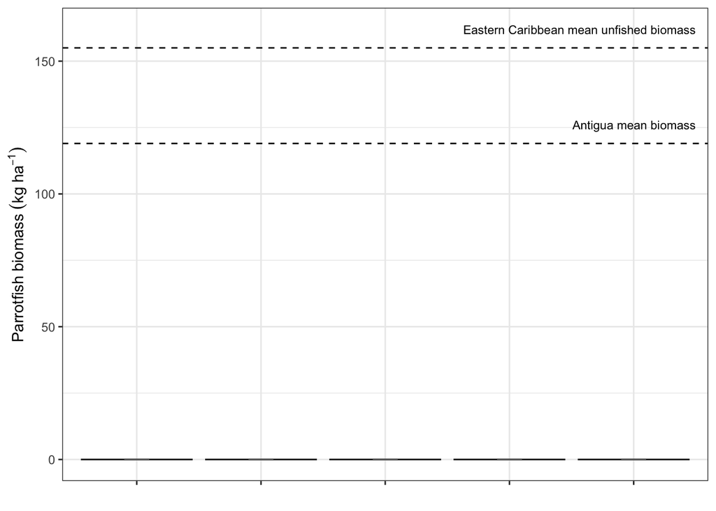

```r
ggplot(rf_fish_fam_site %>%
        filter(family_c == "Scaridae"),
       aes(x = site, y = bm_mean)) +
  geom_col(color = "black", fill = "cadetblue3", alpha = 0.8, stat = "identity", position = position_dodge()) +
  geom_errorbar(aes(ymin = bm_mean - bm_se, ymax = bm_mean + bm_se), width = .2, color = "gray40",
                 position = position_dodge(.9)) +
  geom_hline(yintercept = 155, linetype = "dashed", color = "black") +
  annotate("text", x = 5.5, y = 162, size = 3, hjust = 1, label=c('Eastern Caribbean mean unfished biomass')) +
  geom_hline(yintercept = 119, linetype = "dashed", color = "black") +
  annotate("text", x = 5.5, y = 126, size = 3, hjust = 1, label=c('Antigua mean biomass')) +
  labs(x = "", y = expression(Parrotfish~biomass~(kg~ha^-1))) +
  theme_bw() +
  theme(axis.text.x = element_blank())
```

```r
ggsave(here("jumby_baseline", "figs", "reef_scarid_bm.png"), height = 3, width = 5)
```

#### Acanthurid biomass by site

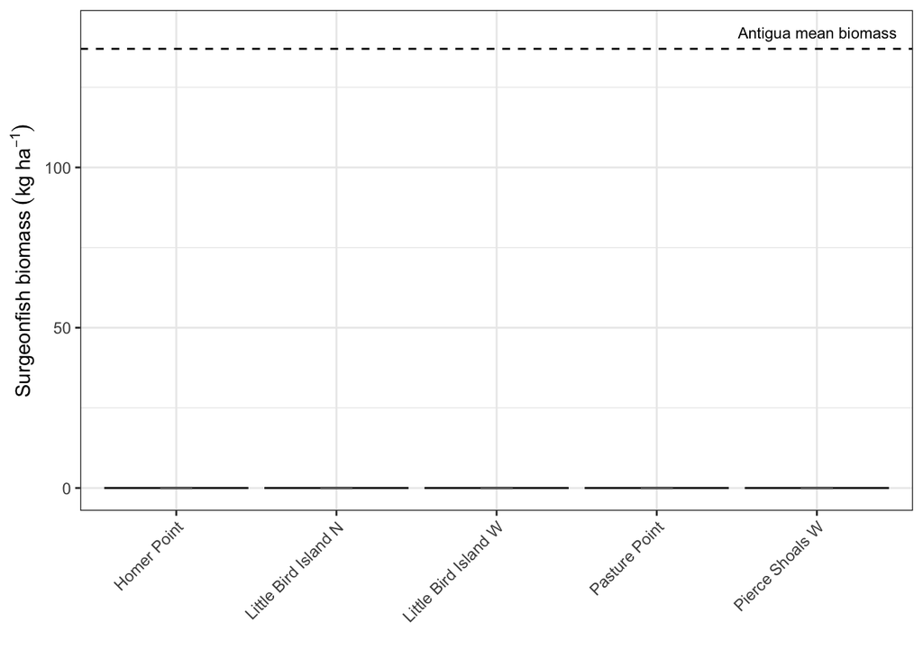

```r
ggplot(rf_fish_fam_site %>%
        filter(family_c == "Acanthuridae"),
       aes(x = site, y = bm_mean)) +
  geom_col(color = "black", fill = "cadetblue3", alpha = 0.8, stat = "identity", position = position_dodge()) +
  geom_errorbar(aes(ymin = bm_mean - bm_se, ymax = bm_mean + bm_se), width = .2, color = "gray40",
                 position = position_dodge(.9)) +
  geom_hline(yintercept = 137, linetype = "dashed", color = "black") +
  annotate("text", x = 5.5, y = 142, size = 3, hjust = 1, label=c('Antigua mean biomass')) +
  labs(x = "", y = expression(Surgeonfish~biomass~(kg~ha^-1))) +
  theme_bw() +
  theme(axis.text.x = element_text(hjust = 1, angle = 45))
```

```r
ggsave(here("jumby_baseline", "figs", "reef_acan_bm.png"), height = 4, width = 5)
```

### Fish lengths

#### Length distributions of all fish by site

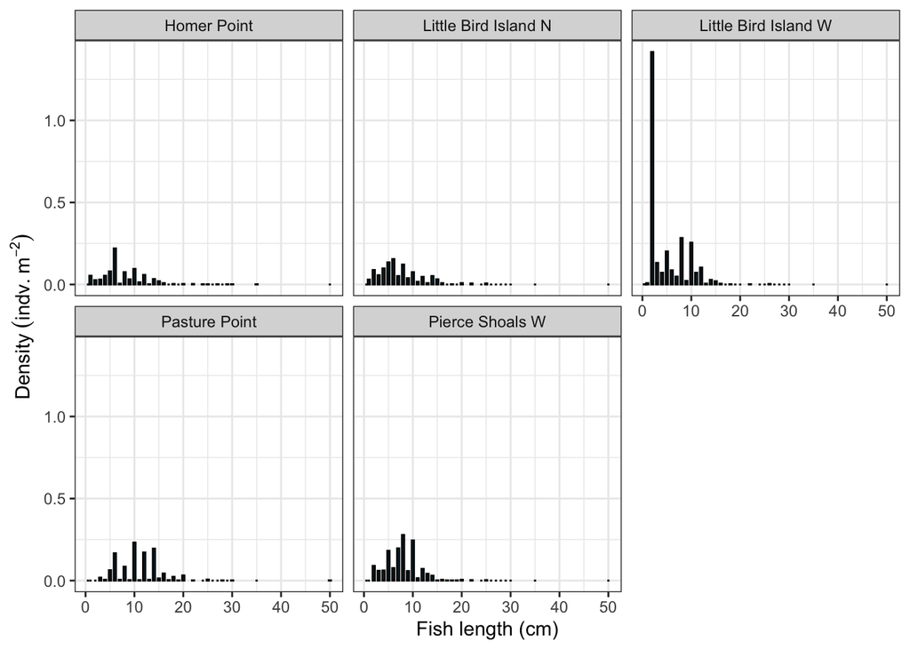

```r
rf_fish_length <- rf_fish %>%
  expand(nesting(site, transect), length) %>%
  left_join(rf_fish %>%
        group_by(site, transect, length) %>%
        summarize(count = n())) %>%
  mutate(count = as.numeric(count),
         count = if_else(is.na(count), 0, count),
         density = count/120) %>% # indv./m2
  group_by(site, length) %>%
  summarize(density_mean = mean(density),
            density_se = sd(density)/sqrt(n()))

ggplot(rf_fish_length, aes(x = length, y = density_mean)) +
  geom_col(fill = "deepskyblue4", alpha = 0.9, color = "black") +
  facet_wrap(. ~ site) +
  labs(x = "Fish length (cm)", y = expression(Density~(indv.~m^-2))) +
  theme_bw()
```

#### Length distributions of scarids at each site

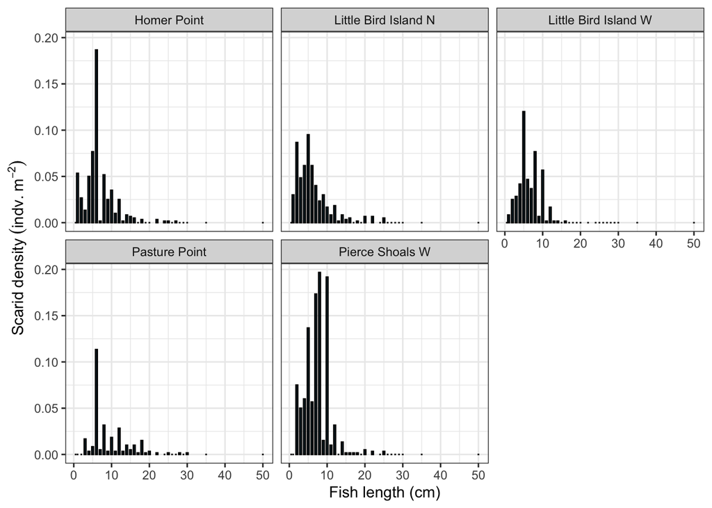

```r
rf_fish_length_scarids <- rf_fish %>%
  expand(nesting(site, transect), length) %>%
  left_join(rf_fish %>%
        filter(family == "Scaridae") %>%
        group_by(site, transect, length) %>%
        summarize(count = n())) %>%
  mutate(count = as.numeric(count),
         count = if_else(is.na(count), 0, count),
         density = count/120) %>% # invd/m2
  group_by(site, length) %>%
  summarize(density_mean = mean(density),
            density_se = sd(density)/sqrt(n()))

ggplot(rf_fish_length_scarids, aes(x = length, y = density_mean)) +
  geom_col(fill = "deepskyblue4", alpha = 0.9, color = "black") +
  facet_wrap(. ~ site) +
  labs(x = "Fish length (cm)", y = expression(Scarid~density~(indv.~m^-2))) +
  theme_bw()
```

#### Violin plots with pooled data from each site * Each site had 5 transects, so pooling all fish observed across all transects per site to make violins work

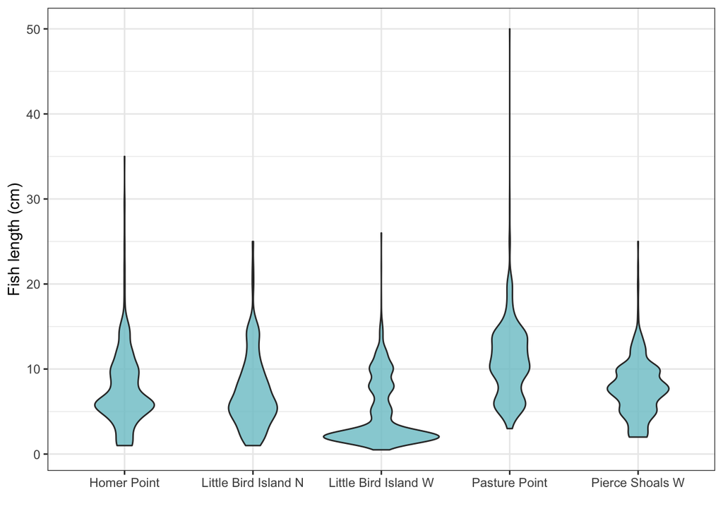

```r
ggplot(rf_fish, aes(x = site, y = length)) +
  geom_violin(fill = "cadetblue3", alpha = 0.8) +
  labs(x = "", y = "Fish length (cm)") +
  theme_bw()
```

```r
ggsave(here("jumby_baseline", "figs", "reef_fish_violin.png"))
```